# Project_Group_7_R_mixtools

Runwei Wang

November 27, 2018

### R (mixtools)

#### 0. General information

In this sectioin we will use package `mixtools` to fit finite mixtures of regression models. The mixtools package for R provides a set of functions for fitting a variety of finite mixture models. We are able to get posterior probabilities with the help of function `regmixEM` in this package. Also, package `caret` provides a convinient way to generate a confusion matrix based on final result, which gives demonstration of the performance of an algorithm.

#### 1. Preparation

We will use the packages shown below in the following analysis.

```r
library(mixtools)
library(tidyverse)
library(data.table)
library(ggplot2)
library(caret)
```

#### 2. Load the dataset into the R

First we load data into R from the website by using `fread` from package `data.table`.

```r
wine = fread("https://archive.ics.uci.edu/ml/machine-learning-databases/wine/wine.data", header = F)
```

We change names for all variables for later use.

```r
names(wine) = c("Class", "Alcohol", "Malic_acid", "Ash", "Alcalinity_of_ash", "Magnesium", "Total_phenols", "Flavanoids", "Nonflavanoid_phenols", "Proanthocyanins", "Color_intensity", "Hue", "OD280/OD315_of_diluted_wines", "Proline")
pred = cbind(wine$Total_phenols, rep(1, 178))
```

#### 3. Pattern of the selected variables

Next we plot the density plot of response `Color_intensity`, the density plot of predictor `Total_phenols`, and the histogram of the ground truth class `Class` to see their patterns. As shown below, the distribution of `Color_intensity` is right-skewed, `Total_phenols` clearly has two peaks, and histogram represents the number of observations of class 1, 2, 3 respectively.

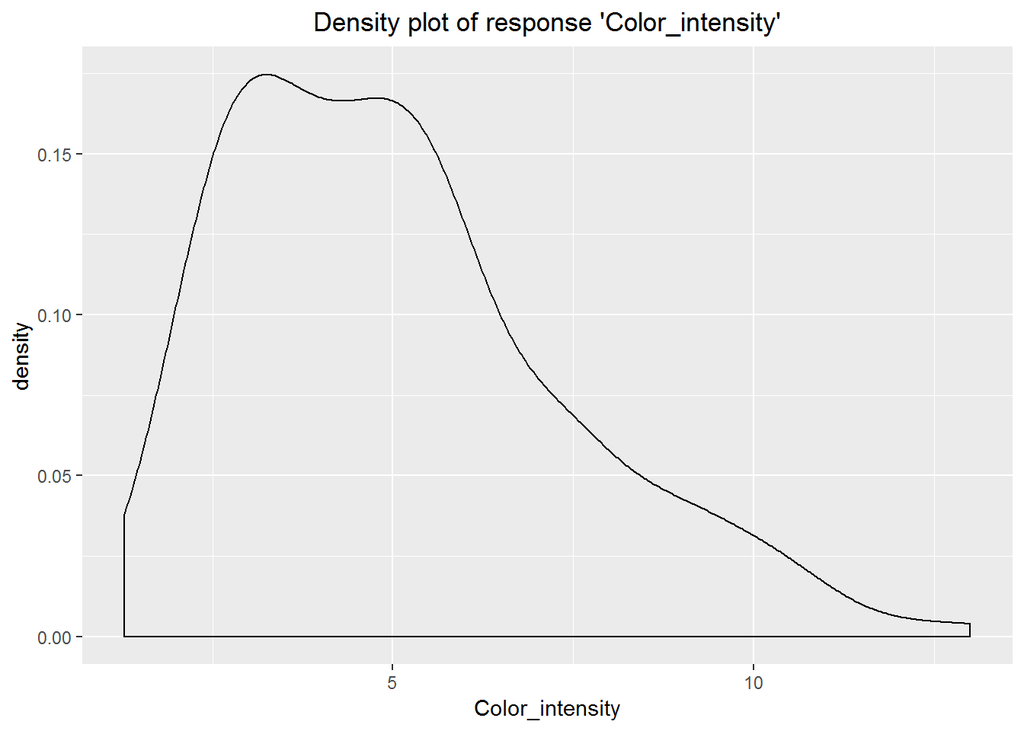

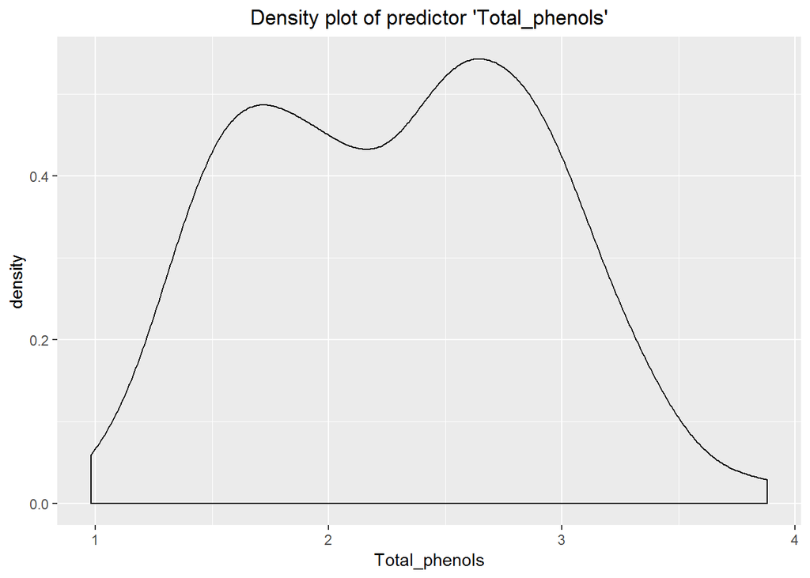

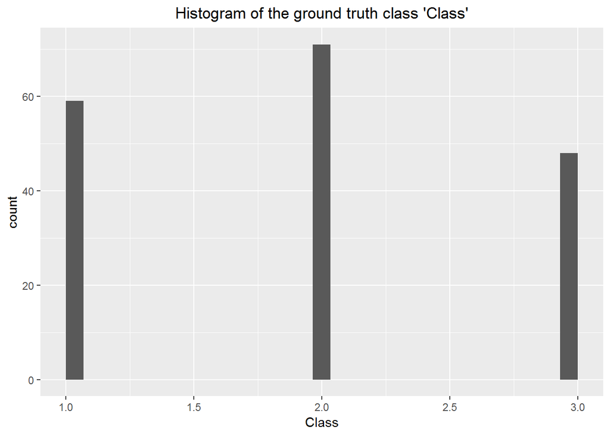

#### 4. Model fitting

In R, we can obtain our fitted model by calling function “regmixEM” from package `mixtools`. Here in order to keep consistent with results obtained in Stata, we set the initial values as shown below.

```r
winereg <- regmixEM(wine$Color_intensity,
                    pred,
                    lambda = c(0.3370787, 0.3314607, 0.3314607),
                    beta = matrix(c(2.6478173, 2.3281364, 3.2570108, -3.3001476, 2.9323563, -4.4052074), nrow = 2, ncol = 3),
                    sigma = sqrt(c(5.3676108, .41571224, .92670911)),
                    addintercept = FALSE,
                    k = 3)
```

```
## number of iterations= 284
```

#### 5. Results of model fitting

The fitting result of our regression model is shown as below. Here can we get our parameters’ estimators.

```r
summary(winereg)
```

```
## summary of regmixEM object:
##           comp 1   comp 2   comp 3
## lambda  0.417095 0.352297 0.230607
## sigma   2.306772 0.765854 0.463415
## beta1  -0.778532 1.326651 0.381015
## beta2   8.382019 1.508313 1.747907
## loglik at estimate:  -372.4699
```

#### 6. Clustering

The clustering number of each observation is decided by its column number with maximum posterior probabilities value. Here we show the first 6 rows of observations.

```r
post = winereg$posterior
post = as.data.frame(post)
names(post) = c('Class_1', 'Class_2', 'Class_3')
knitr::kable(head(post), align = 'c', caption = 'Table 1: First 6 lines of posterior probabilities.')
```

Table 1: First 6 lines of posterior probabilities.

| Class_1 | Class_2 | Class_3 |
| --- | --- | --- |
| 0.3067873 | 0.6932127 | 0.0000000 |
| 0.2815310 | 0.7160642 | 0.0024048 |
| 0.3140397 | 0.6859603 | 0.0000000 |
| 0.4288006 | 0.5711994 | 0.0000000 |
| 0.3583267 | 0.6346351 | 0.0070383 |
| 0.4215793 | 0.5784207 | 0.0000000 |

#### 7. Classification

Then we generate an aggregation table: median of posterior probabilities, by `Class`.

```r
res = cbind(post, wine$Class)
res = as.data.frame(res)
names(res) = c('Class_1', 'Class_2', 'Class_3', 'Class_true')
med = group_by(res, Class_true) %>%
  summarise(med1 = median(Class_1),
            med2 = median(Class_2),
            med3 = median(Class_3))
knitr::kable(med, align = 'c', caption = "Table 2: Median of posterior probabilities, by 'Class'")
```

Table 2: Median of posterior probabilities, by ‘Class’

| Class_true | med1 | med2 | med3 |
| --- | --- | --- | --- |
| 1 | 0.3055787 | 0.6804114 | 0.0000003 |
| 2 | 0.1076153 | 0.1362883 | 0.7402980 |
| 3 | 0.9999023 | 0.0000977 | 0.0000000 |

Similar as results in Stata, we found that Cluster 1, 2, and 3 represent Class 3, 1, and 2, respectively. Here we compare its true class with classification number to get the accuracy of classification.

```r
final = data.frame()
for (i in 1:178)
{
  final[i,1] = which.max(post[i,])
}
final[,2] = final[,1]-1
final[,2][final[,2] == 0] = 3

post1 = cbind(post, rep(0,178))
for (i in 1:178)
{
  post1[i,4] = max(post[i,])
}
post2 = as.data.frame(post1)
res = cbind(post2, final, wine$Class, rep(0,178))
res[,8][res[,6] == res[,7]] = 1
names(res) = c('C1', 'C2', 'C3', 'Max', 'Cluster', 'Class_pred', 'Class_true', 'match')
clustering = group_by(res, Class_true) %>%
  summarise(Right_percentage = sum(match)/n())
knitr::kable(clustering, align = 'c', caption = 'Table 3: Accuracy within each class.')
```

Table 3: Accuracy within each class.

| Class_true | Right_percentage |
| --- | --- |
| 1 | 0.8305085 |
| 2 | 0.6760563 |
| 3 | 0.8125000 |

#### 8. Accuracy of the classification

Finally, we use function `confusionMatrix` to generate a confusion matrix. Same as this in Stata, using same initial values helps working out same results. And we can see that the accuracy of our fitted model is 0.764.

```r
x = factor(res$Class_pred)
y = factor(res$Class_true)
z = confusionMatrix(x, y)
z$table
```

```
##           Reference
## Prediction  1  2  3
##          1 49 20  9
##          2  2 48  0
##          3  8  3 39
```